# 重賞レース予測レポート【毎時自動更新中】

作成日時: 2026/03/15 15:06:30

☞ [マニュアル(pdf)](https://ryutoro-galois.github.io/keiba-predictor/manual/manual.pdf)

☞ 過去6年の同一レース結果: [2025年](https://ryutoro-galois.github.io/keiba-predictor/report/PredResult_2025y_raceDate_20250315_20250316.html), [2024年](https://ryutoro-galois.github.io/keiba-predictor/report/PredResult_2024y_raceDate_20240309_20240310.html), [2023年](https://ryutoro-galois.github.io/keiba-predictor/report/PredResult_2023y_raceDate_20230311_20230312.html), [2022年](https://ryutoro-galois.github.io/keiba-predictor/report/PredResult_2022y_raceDate_20220312_20220313.html), [2021年](https://ryutoro-galois.github.io/keiba-predictor/report/PredResult_2021y_raceDate_20210313_20210314.html), [2020年](https://ryutoro-galois.github.io/keiba-predictor/report/PredResult_2020y_raceDate_20200314_20200315.html)

☞ 過去4週間の別レース結果: [1週前(3/7-8)](https://ryutoro-galois.github.io/keiba-predictor/report/PredResult_2026y_raceDate_20260307_20260308.html), [2週前(2/28-3/1)](https://ryutoro-galois.github.io/keiba-predictor/report/PredResult_2026y_raceDate_20260228_20260301.html), [3週前(2/21-22)](https://ryutoro-galois.github.io/keiba-predictor/report/PredResult_2026y_raceDate_20260221_20260222.html), [4週前(2/14-15)](https://ryutoro-galois.github.io/keiba-predictor/report/PredResult_2026y_raceDate_20260214_20260215.html)

☞ netkeiba: [阪神スプリングジャンプ(JGⅡ)](https://race.netkeiba.com/race/shutuba.html?race_id=202609010708&rf=race_list), [スプリングステークス(GⅡ)](https://race.netkeiba.com/race/shutuba.html?race_id=202606020611&rf=race_list), [金鯱賞(GⅡ)](https://race.netkeiba.com/race/shutuba.html?race_id=202607010211&rf=race_list)

## 0. 推し馬予測 (AI予測)

### 【阪神スプリングジャンプ(J.GⅡ) 2026/03/14(土)】

- 本命(◎): 1-3着内確率(勝負強さ)が1位の馬
- 対抗(◯): 1-3着内確率が2-N位(20%程度以上)の中で予測タイムが最も速い馬
- 3番手(▲): 1-3着内確率が2-N位(20%程度以上)のでダークホース確率が最も高い馬
- 穴: ダークホース確率が上位1-M位(40%程度以上)の中で1-3着内確率が最も高い馬

| 推し馬 | 枠番 | 馬番 | 人気 | オッズ | 馬名 | 騎手 | 調教師 | 予測タイム(sec) | 1_順位 | 1-3着内確率(%) | 2_順位 | ﾀﾞｰｸﾎｰｽ確率(%) | 3_順位 |
| --- | --- | --- | --- | --- | --- | --- | --- | --- | --- | --- | --- | --- | --- |
| 本命(◎) | 8 | 9 | 3 | 5.6 | ディナースタ | 高田潤 | 辻野泰之 | 269.8 | 2 | 26.8 | 1 | 0.4 | 10 |
| 対抗(◯) | 2 | 2 | 1 | 1.5 | エコロデュエル | 草野太郎 | 岩戸孝樹 | 260.7 | 1 | 23.4 | 2 | 0.4 | 8 |
| 3番手(▲) | 5 | 5 | 10 | 232.3 | ポリトナリティー | 五十嵐雄祐 | 和田雄二 | 277.5 | 4 | 11.2 | 4 | 69.8 | 1 |
| 穴 | 4 | 4 | 5 | 55.7 | レッドファーロ | 小野寺祐太 | 松永幹夫 | 269.8 | 3 | 8.4 | 6 | 1.5 | 6 |

### 【スプリングステークス(GⅡ) 2026/03/15(日)】

- 本命(◎): 1-3着内確率(勝負強さ)が1位の馬
- 対抗(◯): 1-3着内確率が2-N位(20%程度以上)の中で予測タイムが最も速い馬
- 3番手(▲): 1-3着内確率が2-N位(20%程度以上)のでダークホース確率が最も高い馬
- 穴: ダークホース確率が上位1-M位(40%程度以上)の中で1-3着内確率が最も高い馬

| 推し馬 | 枠番 | 馬番 | 人気 | オッズ | 馬名 | 騎手 | 調教師 | 予測タイム(sec) | 1_順位 | 1-3着内確率(%) | 2_順位 | ﾀﾞｰｸﾎｰｽ確率(%) | 3_順位 |
| --- | --- | --- | --- | --- | --- | --- | --- | --- | --- | --- | --- | --- | --- |
| 本命(◎) | 8 | 15 | 7 | 17.1 | アウダーシア | 津村明秀 | 手塚貴久 | 115.8 | 9 | 37.8 | 1 | 1.3 | 9 |
| 対抗(◯) | 5 | 10 | 3 | 12.7 | サノノグレーター | 田辺裕信 | 尾形和幸 | 108.2 | 2 | 26.8 | 3 | 1.0 | 14 |
| 穴 | 3 | 6 | 9 | 23.6 | ガリレア | 石橋脩 | 清水英克 | 108.2 | 4 | 12.8 | 6 | 34.3 | 2 |

### 【金鯱賞(GⅡ) 2026/03/15(日)】

- 本命(◎): 1-3着内確率(勝負強さ)が1位の馬
- 対抗(◯): 1-3着内確率が2-N位(20%程度以上)の中で予測タイムが最も速い馬
- 3番手(▲): 1-3着内確率が2-N位(20%程度以上)のでダークホース確率が最も高い馬
- 穴: ダークホース確率が上位1-M位(40%程度以上)の中で1-3着内確率が最も高い馬

| 推し馬 | 枠番 | 馬番 | 人気 | オッズ | 馬名 | 騎手 | 調教師 | 予測タイム(sec) | 1_順位 | 1-3着内確率(%) | 2_順位 | ﾀﾞｰｸﾎｰｽ確率(%) | 3_順位 |
| --- | --- | --- | --- | --- | --- | --- | --- | --- | --- | --- | --- | --- | --- |
| 本命(◎) | 3 | 4 | 6 | 10.5 | アーバンシック | 三浦皇成 | 武井亮 | 121.8 | 2 | 30.2 | 1 | 1.8 | 8 |
| 対抗(◯) | 2 | 2 | 4 | 8.2 | ジューンテイク | 武豊 | 武英智 | 127.8 | 10 | 24.2 | 2 | 1.3 | 9 |
| 3番手(▲) | 3 | 3 | 5 | 8.5 | ジョバンニ | 松山弘平 | 杉山晴紀 | 127.8 | 8 | 16.8 | 5 | 1.1 | 10 |
| 穴 | 8 | 14 | 12 | 67.4 | サフィラ | 丸山元気 | 池添学 | 126.8 | 5 | 9.4 | 8 | 73.6 | 1 |

## 1. 予測チャート (タイム/勝負強さ)

### 【阪神スプリングジャンプ(J.GⅡ)】

2026/03/14(土), 09_阪神, 障芝3900m

[interactive chart not shown]

### 【スプリングステークス(GⅡ)】

2026/03/15(日), 06_中山, 芝右1800m

[interactive chart not shown]

### 【金鯱賞(GⅡ)】

2026/03/15(日), 07_中京, 芝左2000m

[interactive chart not shown]

## 2. オッズモニタリング (毎時)

### 【阪神スプリングジャンプ】

[interactive chart not shown]

### 【スプリングステークス】

[interactive chart not shown]

### 【金鯱賞】

[interactive chart not shown]

## 3. 出馬表

### 【阪神スプリングジャンプ 2026/03/14(土) 】

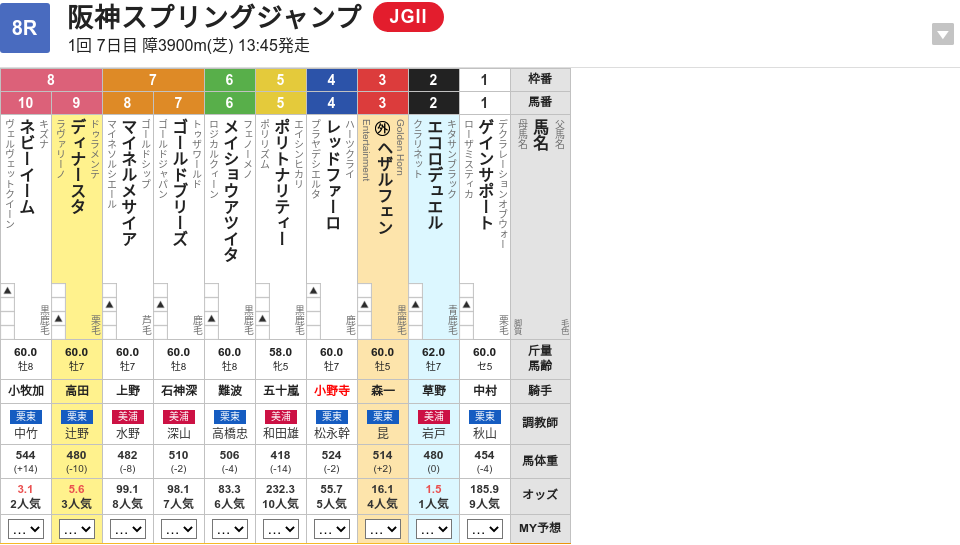

### 【スプリングステークス 2026/03/15(日) 】

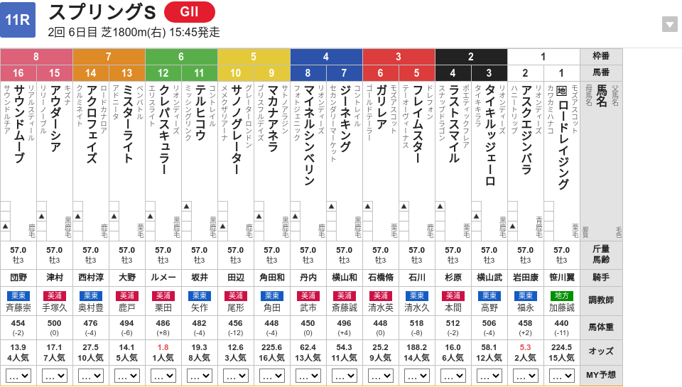

### 【金鯱賞 2026/03/15(日) 】

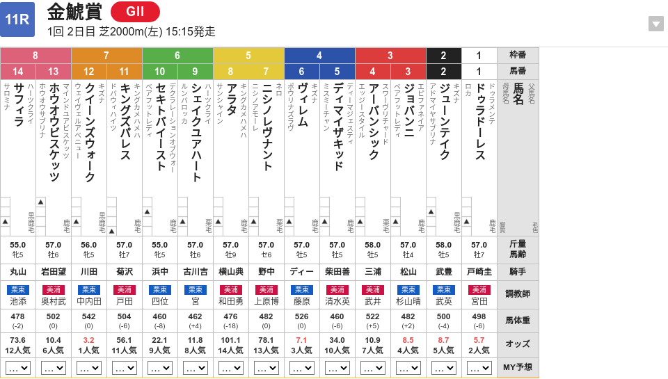

## 4. 単勝予測結果

### 【阪神スプリングジャンプ(J.GⅡ) 2026/03/14(土)】

| 枠番 | 馬番 | 人気 | オッズ | 馬名 | 騎手 | 調教師 | 予測タイム(sec) | 1_順位 | 1-3着内確率(%) | 2_順位 | ﾀﾞｰｸﾎｰｽ確率(%) | 3_順位 |
| --- | --- | --- | --- | --- | --- | --- | --- | --- | --- | --- | --- | --- |
| 1 | 1 | 9 | 185.9 | ゲインサポート | 中村将之 | 秋山真一郎 | 278.2 | 7.0 | 4.3 | 7 | 11.4 | 4 |
| 2 | 2 | 1 | 1.5 | エコロデュエル | 草野太郎 | 岩戸孝樹 | 260.7 | 1.0 | 23.4 | 2 | 0.4 | 8 |
| 3 | 3 | 4 | 16.1 | ヘザルフェン | 森一馬 | 昆貢 | 278.1 | 6.0 | 10.6 | 5 | 1.0 | 7 |
| 4 | 4 | 5 | 55.7 | レッドファーロ | 小野寺祐太 | 松永幹夫 | 269.8 | 3.0 | 8.4 | 6 | 1.5 | 6 |
| 5 | 5 | 10 | 232.3 | ポリトナリティー | 五十嵐雄祐 | 和田雄二 | 277.5 | 4.0 | 11.2 | 4 | 69.8 | 1 |
| 6 | 6 | 6 | 83.3 | メイショウアツイタ | 難波剛健 | 高橋義忠 | 278.9 | 9.5 | 2.5 | 8 | 11.5 | 3 |
| 7 | 7 | 7 | 98.1 | ゴールドブリーズ | 石神深一 | 深山雅史 | 278.9 | 9.5 | 2.4 | 10 | 10.6 | 5 |
| 7 | 8 | 8 | 99.1 | マイネルメサイア | 上野翔 | 水野貴広 | 278.0 | 5.0 | 2.4 | 9 | 12.2 | 2 |
| 8 | 9 | 3 | 5.6 | ディナースタ | 高田潤 | 辻野泰之 | 269.8 | 2.0 | 26.8 | 1 | 0.4 | 10 |
| 8 | 10 | 2 | 3.1 | ネビーイーム | 小牧加矢太 | 中竹和也 | 278.3 | 8.0 | 17.7 | 3 | 0.4 | 9 |

### 【スプリングステークス(GⅡ) 2026/03/15(日)】

| 枠番 | 馬番 | 人気 | オッズ | 馬名 | 騎手 | 調教師 | 予測タイム(sec) | 1_順位 | 1-3着内確率(%) | 2_順位 | ﾀﾞｰｸﾎｰｽ確率(%) | 3_順位 |
| --- | --- | --- | --- | --- | --- | --- | --- | --- | --- | --- | --- | --- |
| 1 | 1 | 16 | 220.0 | ロードレイジング | 笹川翼 | 加藤誠一 | 117.7 | 12 | 2.8 | 14 | 9.2 | 8 |
| 1 | 2 | 2 | 5.4 | アスクエジンバラ | 岩田康誠 | 福永祐一 | 108.5 | 7 | 35.7 | 2 | 0.5 | 16 |
| 2 | 3 | 12 | 56.6 | タイキルッジェーロ | 横山武史 | 高野友和 | 118.0 | 14 | 2.9 | 13 | 13.7 | 7 |
| 2 | 4 | 6 | 15.7 | ラストスマイル | 杉原誠人 | 本間忍 | 108.2 | 3 | 19.1 | 5 | 1.1 | 11 |
| 3 | 5 | 14 | 181.9 | フレイムスター | 石川裕紀人 | 清水久詞 | 118.2 | 15 | 3.4 | 12 | 14.2 | 5 |
| 3 | 6 | 9 | 23.6 | ガリレア | 石橋脩 | 清水英克 | 108.2 | 4 | 12.8 | 6 | 34.3 | 2 |
| 4 | 7 | 11 | 55.7 | ジーネキング | 横山和生 | 斎藤誠 | 108.3 | 5 | 6.5 | 11 | 34.7 | 1 |
| 4 | 8 | 13 | 62.2 | マイネルシンベリン | 丹内祐次 | 武市康男 | 118.3 | 16 | 2.3 | 15 | 19.1 | 4 |
| 5 | 9 | 15 | 217.5 | マカナアネラ | 角田大和 | 角田晃一 | 117.9 | 13 | 2.2 | 16 | 21.8 | 3 |
| 5 | 10 | 3 | 12.7 | サノノグレーター | 田辺裕信 | 尾形和幸 | 108.2 | 2 | 26.8 | 3 | 1.0 | 14 |

[output cut: 6 more lines]

### 【金鯱賞(GⅡ) 2026/03/15(日)】

| 枠番 | 馬番 | 人気 | オッズ | 馬名 | 騎手 | 調教師 | 予測タイム(sec) | 1_順位 | 1-3着内確率(%) | 2_順位 | ﾀﾞｰｸﾎｰｽ確率(%) | 3_順位 |
| --- | --- | --- | --- | --- | --- | --- | --- | --- | --- | --- | --- | --- |
| 1 | 1 | 2 | 6.3 | ドゥラドーレス | 戸崎圭太 | 宮田敬介 | 126.8 | 6 | 19.1 | 3 | 0.5 | 13 |
| 2 | 2 | 4 | 8.2 | ジューンテイク | 武豊 | 武英智 | 127.8 | 10 | 24.2 | 2 | 1.3 | 9 |
| 3 | 3 | 5 | 8.5 | ジョバンニ | 松山弘平 | 杉山晴紀 | 127.8 | 8 | 16.8 | 5 | 1.1 | 10 |
| 3 | 4 | 6 | 10.5 | アーバンシック | 三浦皇成 | 武井亮 | 121.8 | 2 | 30.2 | 1 | 1.8 | 8 |
| 4 | 5 | 10 | 31.0 | ディマイザキッド | 柴田善臣 | 清水英克 | 128.0 | 11 | 5.3 | 11 | 35.8 | 5 |
| 4 | 6 | 3 | 6.6 | ヴィレム | Ｍ．ディー | 藤原英昭 | 126.5 | 4 | 12.0 | 6 | 0.9 | 11 |
| 5 | 7 | 13 | 68.0 | ニシノレヴナント | 野中悠太郎 | 上原博之 | 129.3 | 14 | 2.0 | 14 | 29.4 | 6 |
| 5 | 8 | 14 | 86.6 | アラタ | 横山典弘 | 和田勇介 | 122.3 | 3 | 2.8 | 12 | 36.0 | 4 |
| 6 | 9 | 8 | 11.2 | シェイクユアハート | 古川吉洋 | 宮徹 | 128.2 | 12 | 6.5 | 10 | 18.1 | 7 |
| 6 | 10 | 9 | 20.8 | セキトバイースト | 浜中俊 | 四位洋文 | 127.8 | 9 | 7.5 | 9 | 39.1 | 2 |

[output cut: 4 more lines]

## 5. 人気と着順の乖離率推移

### 【阪神スプリングジャンプ_2001y_2019y】

[interactive chart not shown]

### 【スプリングステークス_1990y_2019y】

[interactive chart not shown]

### 【金鯱賞_1990y_2019y】

[interactive chart not shown]

### 【阪神スプリングジャンプ_2001y_2019y】

| No | 開催年 | 不整合率(%) | 頭数 | 人気別着順(1-3位) | 人気別着順(全体) |
| --- | --- | --- | --- | --- | --- |
| 19 | 2019 | 8.7 | 12頭 | 1-2-3 | 1\|2\|3\|7\|4\|9\|8\|6\|5\|10\|11\|12 |
| 18 | 2018 | 20.6 | 8頭 | 1-3-2 | 1\|3\|2\|7\|4\|6\|5\|8 |
| 17 | 2017 | 9.3 | 11頭 | 1-2-3 | 1\|2\|3\|7\|9\|6\|4\|5\|8\|10\|11 |
| 16 | 2016 | 23.7 | 12頭 | 2-1-5 | 2\|1\|5\|3\|6\|8\|13\|9\|4\|12\|10\|11 |
| 15 | 2015 | 50.8 | 12頭 | 4-6-5 | 4\|6\|5\|1\|3\|10\|7\|12\|13\|2\|9\|8 |
| 14 | 2014 | 44.0 | 10頭 | 4-1-6 | 4\|1\|6\|11\|12\|10\|8\|3\|5\|9 |
| 13 | 2013 | 21.1 | 11頭 | 5-1-2 | 5\|1\|2\|9\|4\|6\|7\|8\|10\|12\|11 |
| 12 | 2012 | 7.2 | 10頭 | 2-3-4 | 2\|3\|4\|11\|6\|5\|10\|8\|9\|7 |
| 11 | 2011 | 63.3 | 13頭 | 9-5-11 | 9\|5\|11\|8\|4\|1\|7\|6\|12\|10\|14\|3\|13 |
| 10 | 2010 | 41.9 | 14頭 | 2-3-12 | 2\|3\|12\|7\|11\|8\|1\|13\|5\|9\|6\|10\|14\|4 |

[output cut: 9 more lines]

### 【スプリングステークス_1990y_2019y】

| No | 開催年 | 不整合率(%) | 頭数 | 人気別着順(1-3位) | 人気別着順(全体) |
| --- | --- | --- | --- | --- | --- |
| 30 | 2019 | 14.8 | 15頭 | 1-6-2 | 1\|6\|2\|3\|8\|12\|4\|9\|11\|14\|7\|5\|13\|10\|15 |
| 29 | 2018 | 54.6 | 18頭 | 4-7-2 | 4\|7\|2\|3\|14\|6\|11\|8\|17\|13\|15\|5\|10\|16\|1\|18\|9\|12 |
| 28 | 2017 | 43.5 | 13頭 | 2-11-4 | 2\|11\|4\|13\|6\|8\|5\|10\|1\|9\|3\|7\|12 |
| 27 | 2016 | 51.2 | 16頭 | 3-7-2 | 3\|7\|2\|4\|11\|5\|1\|9\|8\|6\|15\|12\|10\|14\|13\|16 |
| 26 | 2015 | 46.6 | 18頭 | 5-2-7 | 5\|2\|7\|10\|11\|3\|8\|16\|14\|1\|13\|4\|17\|9\|12\|6\|18\|15 |
| 25 | 2014 | 43.2 | 15頭 | 10-2-7 | 10\|2\|7\|8\|4\|5\|1\|12\|3\|9\|11\|6\|14\|13\|15 |
| 24 | 2013 | 32.3 | 18頭 | 1-5-6 | 1\|5\|6\|9\|15\|18\|3\|2\|10\|11\|7\|12\|4\|17\|14\|8\|13\|16 |
| 23 | 2012 | 49.4 | 15頭 | 4-11-13 | 4\|11\|13\|2\|7\|6\|5\|14\|12\|1\|3\|15\|10\|8\|9 |
| 22 | 2011 | 31.5 | 18頭 | 1-4-8 | 1\|4\|8\|5\|12\|6\|13\|11\|7\|9\|14\|17\|2\|16\|3\|10\|18\|15 |
| 21 | 2010 | 49.0 | 17頭 | 10-5-3 | 10\|5\|3\|1\|7\|9\|13\|4\|15\|2\|6\|8\|12\|11\|14\|16\|17 |

[output cut: 20 more lines]

### 【金鯱賞_1990y_2019y】

| No | 開催年 | 不整合率(%) | 頭数 | 人気別着順(1-3位) | 人気別着順(全体) |
| --- | --- | --- | --- | --- | --- |
| 30 | 2019 | 28.7 | 13頭 | 2-5-1 | 2\|5\|1\|4\|3\|6\|9\|13\|7\|8\|11\|12\|10 |
| 29 | 2018 | 11.7 | 9頭 | 1-8-2 | 1\|8\|2\|3\|6\|5\|7\|4\|9 |
| 28 | 2017 | 28.2 | 16頭 | 1-7-13 | 1\|7\|13\|11\|9\|3\|2\|4\|10\|6\|5\|15\|16\|12\|14\|8 |
| 27 | 2016 | 56.5 | 13頭 | 4-9-6 | 4\|9\|6\|2\|3\|7\|12\|8\|1\|10\|5\|11\|13 |
| 26 | 2015 | 45.4 | 12頭 | 5-1-4 | 5\|1\|4\|8\|6\|3\|7\|2\|9\|12\|11\|10 |
| 25 | 2014 | 22.4 | 17頭 | 1-4-2 | 1\|4\|2\|6\|5\|8\|7\|14\|12\|9\|16\|10\|13\|17\|3\|11\|15 |
| 24 | 2013 | 73.0 | 14頭 | 3-6-8 | 3\|6\|8\|5\|7\|4\|9\|13\|10\|2\|11\|14\|12\|1 |
| 23 | 2012 | 37.9 | 12頭 | 6-8-4 | 6\|8\|4\|9\|11\|1\|10\|2\|12\|3\|7\|5 |
| 22 | 2011 | 18.8 | 16頭 | 1-2-3 | 1\|2\|3\|11\|9\|8\|14\|13\|7\|6\|12\|10\|4\|5\|15\|16 |
| 21 | 2010 | 40.3 | 13頭 | 1-6-4 | 1\|6\|4\|7\|8\|9\|3\|2\|10\|11\|12\|13\|14 |

[output cut: 20 more lines]

## 6. 1-3番人気馬の着順分類予測

### 【阪神スプリングジャンプ】

| 分類 | 凡例 | 発生確率(%) | 当該レース | 当該レースランク | 直近1年間 |
| --- | --- | --- | --- | --- | --- |
| 4: 1,2番人気のみ (4_pop12) | 1 \| 2 \| * | 18.3 | 1.14 | 0.66 | 0.37 |
| 1: 1番人気のみ (1_pop1) | 1 \| * \| * | 18.2 | 4.55 | 0.92 | 0.73 |
| 5: 1,3番人気のみ (5_pop13) | 1 \| 3 \| * | 13.7 | 0.00 | 1.73 | 0.00 |
| 8: 1,2,3番人気すべて着外 (8_darkhorse) | * \| * \| * | 13.4 | 0.37 | 0.80 | 0.00 |
| 2: 2番人気のみ (2_pop2) | 2 \| * \| * | 9.6 | 0.00 | 1.10 | 0.00 |
| 7: 1,2,3番人気すべて着内 (7_pop123) | 1 \| 2 \| 3 | 9.6 | 0.27 | 1.10 | 0.38 |
| 6: 2,3番人気のみ (6_pop23) | 2 \| 3 \| * | 8.7 | 2.17 | 1.81 | 0.00 |
| 3: 3番人気のみ (3_pop3) | 3 \| * \| * | 8.5 | 2.12 | 1.52 | 0.00 |

### 【スプリングステークス】

| 分類 | 凡例 | 発生確率(%) | 当該レース | 当該レースランク | 直近1年間 |
| --- | --- | --- | --- | --- | --- |
| 4: 1,2番人気のみ (4_pop12) | 1 \| 2 \| * | 18.3 | 0.72 | 0.60 | 0.27 |
| 1: 1番人気のみ (1_pop1) | 1 \| * \| * | 18.2 | 0.68 | 0.76 | 0.55 |
| 5: 1,3番人気のみ (5_pop13) | 1 \| 3 \| * | 13.7 | 1.38 | 1.38 | 0.00 |
| 8: 1,2,3番人気すべて着外 (8_darkhorse) | * \| * \| * | 13.4 | 1.19 | 1.13 | 0.00 |
| 2: 2番人気のみ (2_pop2) | 2 \| * \| * | 9.6 | 0.68 | 0.88 | 0.00 |
| 7: 1,2,3番人気すべて着内 (7_pop123) | 1 \| 2 \| 3 | 9.6 | 0.00 | 4.80 | 0.00 |
| 6: 2,3番人気のみ (6_pop23) | 2 \| 3 \| * | 8.7 | 2.07 | 1.74 | 0.00 |
| 3: 3番人気のみ (3_pop3) | 3 \| * \| * | 8.5 | 1.00 | 1.44 | 0.00 |

### 【金鯱賞】

| 分類 | 凡例 | 発生確率(%) | 当該レース | 当該レースランク | 直近1年間 |
| --- | --- | --- | --- | --- | --- |
| 1: 1番人気のみ (1_pop1) | 1 \| * \| * | 19.4 | 1.16 | 0.82 | 0.58 |
| 4: 1,2番人気のみ (4_pop12) | 1 \| 2 \| * | 18.4 | 0.51 | 0.60 | 0.28 |
| 5: 1,3番人気のみ (5_pop13) | 1 \| 3 \| * | 14.0 | 1.26 | 1.41 | 0.00 |
| 8: 1,2,3番人気すべて着外 (8_darkhorse) | * \| * \| * | 13.7 | 0.99 | 1.15 | 0.00 |
| 2: 2番人気のみ (2_pop2) | 2 \| * \| * | 9.7 | 3.46 | 0.89 | 0.00 |
| 6: 2,3番人気のみ (6_pop23) | 2 \| 3 \| * | 8.9 | 0.80 | 1.78 | 0.00 |
| 3: 3番人気のみ (3_pop3) | 3 \| * \| * | 8.6 | 3.07 | 1.46 | 0.00 |
| 7: 1,2,3番人気すべて着内 (7_pop123) | 1 \| 2 \| 3 | 7.3 | 1.30 | 3.65 | 0.00 |

## 7. 3連複予測結果

### 【阪神スプリングジャンプ(J.GⅡ) 2026/03/14(土)】

| 分類 | 馬番 | 枠番 | 人気 | 平均予測タイム(sec) | 1-3着内確率(%) | ﾀﾞｰｸﾎｰｽ確率(%) | 馬名 | 騎手 | 調教師 |
| --- | --- | --- | --- | --- | --- | --- | --- | --- | --- |
| 7: 1,2,3番人気すべて着内 (7_pop123) | 2-10-9 | 2-8-8 | 1-2-3 | 269.60 | 1.11 | 0.00 | エコロデュエル \| ネビーイーム \| ディナースタ | 草野太郎 \| 小牧加矢太 \| 高田潤 | 岩戸孝樹 \| 中竹和也 \| 辻野泰之 |
| 5: 1,3番人気のみ (5_pop13) | 2-9-5 | 2-8-5 | 1-3-10 | 269.33 | 0.70 | 0.00 | エコロデュエル \| ディナースタ \| ポリトナリティー | 草野太郎 \| 高田潤 \| 五十嵐雄祐 | 岩戸孝樹 \| 辻野泰之 \| 和田雄二 |
| 5: 1,3番人気のみ (5_pop13) | 2-9-3 | 2-8-3 | 1-3-4 | 269.53 | 0.67 | 0.00 | エコロデュエル \| ディナースタ \| ヘザルフェン | 草野太郎 \| 高田潤 \| 森一馬 | 岩戸孝樹 \| 辻野泰之 \| 昆貢 |
| 6: 2,3番人気のみ (6_pop23) | 10-9-5 | 8-8-5 | 2-3-10 | 275.20 | 0.53 | 0.00 | ネビーイーム \| ディナースタ \| ポリトナリティー | 小牧加矢太 \| 高田潤 \| 五十嵐雄祐 | 中竹和也 \| 辻野泰之 \| 和田雄二 |
| 5: 1,3番人気のみ (5_pop13) | 2-9-4 | 2-8-4 | 1-3-5 | 266.77 | 0.53 | 0.00 | エコロデュエル \| ディナースタ \| レッドファーロ | 草野太郎 \| 高田潤 \| 小野寺祐太 | 岩戸孝樹 \| 辻野泰之 \| 松永幹夫 |
| 6: 2,3番人気のみ (6_pop23) | 10-9-3 | 8-8-3 | 2-3-4 | 275.40 | 0.50 | 0.00 | ネビーイーム \| ディナースタ \| ヘザルフェン | 小牧加矢太 \| 高田潤 \| 森一馬 | 中竹和也 \| 辻野泰之 \| 昆貢 |
| 4: 1,2番人気のみ (4_pop12) | 2-10-5 | 2-8-5 | 1-2-10 | 272.17 | 0.46 | 0.00 | エコロデュエル \| ネビーイーム \| ポリトナリティー | 草野太郎 \| 小牧加矢太 \| 五十嵐雄祐 | 岩戸孝樹 \| 中竹和也 \| 和田雄二 |
| 4: 1,2番人気のみ (4_pop12) | 2-10-3 | 2-8-3 | 1-2-4 | 272.37 | 0.44 | 0.00 | エコロデュエル \| ネビーイーム \| ヘザルフェン | 草野太郎 \| 小牧加矢太 \| 森一馬 | 岩戸孝樹 \| 中竹和也 \| 昆貢 |
| 6: 2,3番人気のみ (6_pop23) | 10-9-4 | 8-8-4 | 2-3-5 | 272.63 | 0.40 | 0.00 | ネビーイーム \| ディナースタ \| レッドファーロ | 小牧加矢太 \| 高田潤 \| 小野寺祐太 | 中竹和也 \| 辻野泰之 \| 松永幹夫 |
| 4: 1,2番人気のみ (4_pop12) | 2-10-4 | 2-8-4 | 1-2-5 | 269.60 | 0.35 | 0.00 | エコロデュエル \| ネビーイーム \| レッドファーロ | 草野太郎 \| 小牧加矢太 \| 小野寺祐太 | 岩戸孝樹 \| 中竹和也 \| 松永幹夫 |

[output cut: 110 more lines]

### 【スプリングステークス(GⅡ) 2026/03/15(日)】

| 分類 | 馬番 | 枠番 | 人気 | 平均予測タイム(sec) | 1-3着内確率(%) | ﾀﾞｰｸﾎｰｽ確率(%) | 馬名 | 騎手 | 調教師 |
| --- | --- | --- | --- | --- | --- | --- | --- | --- | --- |
| 6: 2,3番人気のみ (6_pop23) | 2-10-15 | 1-5-8 | 2-3-7 | 110.83 | 3.63 | 0.00 | アスクエジンバラ \| サノノグレーター \| アウダーシア | 岩田康誠 \| 田辺裕信 \| 津村明秀 | 福永祐一 \| 尾形和幸 \| 手塚貴久 |
| 2: 2番人気のみ (2_pop2) | 2-13-15 | 1-7-8 | 2-5-7 | 112.03 | 3.35 | 0.00 | アスクエジンバラ \| ミスターライト \| アウダーシア | 岩田康誠 \| 大野拓弥 \| 津村明秀 | 福永祐一 \| 鹿戸雄一 \| 手塚貴久 |
| 2: 2番人気のみ (2_pop2) | 2-4-15 | 1-2-8 | 2-6-7 | 110.83 | 2.59 | 0.00 | アスクエジンバラ \| ラストスマイル \| アウダーシア | 岩田康誠 \| 杉原誠人 \| 津村明秀 | 福永祐一 \| 本間忍 \| 手塚貴久 |
| 3: 3番人気のみ (3_pop3) | 10-13-15 | 5-7-8 | 3-5-7 | 111.93 | 2.52 | 0.00 | サノノグレーター \| ミスターライト \| アウダーシア | 田辺裕信 \| 大野拓弥 \| 津村明秀 | 尾形和幸 \| 鹿戸雄一 \| 手塚貴久 |
| 6: 2,3番人気のみ (6_pop23) | 2-10-13 | 1-5-7 | 2-3-5 | 109.50 | 2.38 | 0.00 | アスクエジンバラ \| サノノグレーター \| ミスターライト | 岩田康誠 \| 田辺裕信 \| 大野拓弥 | 福永祐一 \| 尾形和幸 \| 鹿戸雄一 |
| 3: 3番人気のみ (3_pop3) | 10-4-15 | 5-2-8 | 3-6-7 | 110.73 | 1.94 | 0.00 | サノノグレーター \| ラストスマイル \| アウダーシア | 田辺裕信 \| 杉原誠人 \| 津村明秀 | 尾形和幸 \| 本間忍 \| 手塚貴久 |
| 6: 2,3番人気のみ (6_pop23) | 2-10-4 | 1-5-2 | 2-3-6 | 108.30 | 1.83 | 0.00 | アスクエジンバラ \| サノノグレーター \| ラストスマイル | 岩田康誠 \| 田辺裕信 \| 杉原誠人 | 福永祐一 \| 尾形和幸 \| 本間忍 |
| 8: 1,2,3番人気すべて着外 (8_darkhorse) | 13-4-15 | 7-2-8 | 5-6-7 | 111.93 | 1.80 | 0.00 | ミスターライト \| ラストスマイル \| アウダーシア | 大野拓弥 \| 杉原誠人 \| 津村明秀 | 鹿戸雄一 \| 本間忍 \| 手塚貴久 |
| 2: 2番人気のみ (2_pop2) | 2-15-6 | 1-8-3 | 2-7-9 | 110.83 | 1.73 | 0.00 | アスクエジンバラ \| アウダーシア \| ガリレア | 岩田康誠 \| 津村明秀 \| 石橋脩 | 福永祐一 \| 手塚貴久 \| 清水英克 |
| 4: 1,2番人気のみ (4_pop12) | 12-2-15 | 6-1-8 | 1-2-7 | 110.70 | 1.71 | 0.00 | クレパスキュラー \| アスクエジンバラ \| アウダーシア | Ｃ．ルメール \| 岩田康誠 \| 津村明秀 | 栗田徹 \| 福永祐一 \| 手塚貴久 |

[output cut: 550 more lines]

### 【金鯱賞(GⅡ) 2026/03/15(日)】

| 分類 | 馬番 | 枠番 | 人気 | 平均予測タイム(sec) | 1-3着内確率(%) | ﾀﾞｰｸﾎｰｽ確率(%) | 馬名 | 騎手 | 調教師 |
| --- | --- | --- | --- | --- | --- | --- | --- | --- | --- |
| 2: 2番人気のみ (2_pop2) | 1-2-4 | 1-2-3 | 2-4-6 | 125.47 | 1.40 | 0.00 | ドゥラドーレス \| ジューンテイク \| アーバンシック | 戸崎圭太 \| 武豊 \| 三浦皇成 | 宮田敬介 \| 武英智 \| 武井亮 |
| 1: 1番人気のみ (1_pop1) | 12-2-4 | 7-2-3 | 1-4-6 | 122.80 | 1.24 | 0.00 | クイーンズウォーク \| ジューンテイク \| アーバンシック | 川田将雅 \| 武豊 \| 三浦皇成 | 中内田充正 \| 武英智 \| 武井亮 |
| 8: 1,2,3番人気すべて着外 (8_darkhorse) | 2-3-4 | 2-3-3 | 4-5-6 | 125.80 | 1.23 | 0.00 | ジューンテイク \| ジョバンニ \| アーバンシック | 武豊 \| 松山弘平 \| 三浦皇成 | 武英智 \| 杉山晴紀 \| 武井亮 |
| 4: 1,2番人気のみ (4_pop12) | 12-1-4 | 7-1-3 | 1-2-6 | 122.47 | 0.98 | 0.00 | クイーンズウォーク \| ドゥラドーレス \| アーバンシック | 川田将雅 \| 戸崎圭太 \| 三浦皇成 | 中内田充正 \| 宮田敬介 \| 武井亮 |
| 2: 2番人気のみ (2_pop2) | 1-3-4 | 1-3-3 | 2-5-6 | 125.47 | 0.97 | 0.00 | ドゥラドーレス \| ジョバンニ \| アーバンシック | 戸崎圭太 \| 松山弘平 \| 三浦皇成 | 宮田敬介 \| 杉山晴紀 \| 武井亮 |
| 3: 3番人気のみ (3_pop3) | 6-2-4 | 4-2-3 | 3-4-6 | 125.37 | 0.88 | 0.00 | ヴィレム \| ジューンテイク \| アーバンシック | Ｍ．ディー \| 武豊 \| 三浦皇成 | 藤原英昭 \| 武英智 \| 武井亮 |
| 1: 1番人気のみ (1_pop1) | 12-3-4 | 7-3-3 | 1-5-6 | 122.80 | 0.86 | 0.00 | クイーンズウォーク \| ジョバンニ \| アーバンシック | 川田将雅 \| 松山弘平 \| 三浦皇成 | 中内田充正 \| 杉山晴紀 \| 武井亮 |
| 4: 1,2番人気のみ (4_pop12) | 12-1-2 | 7-1-2 | 1-2-4 | 124.47 | 0.79 | 0.00 | クイーンズウォーク \| ドゥラドーレス \| ジューンテイク | 川田将雅 \| 戸崎圭太 \| 武豊 | 中内田充正 \| 宮田敬介 \| 武英智 |
| 2: 2番人気のみ (2_pop2) | 1-2-3 | 1-2-3 | 2-4-5 | 127.47 | 0.78 | 0.00 | ドゥラドーレス \| ジューンテイク \| ジョバンニ | 戸崎圭太 \| 武豊 \| 松山弘平 | 宮田敬介 \| 武英智 \| 杉山晴紀 |
| 8: 1,2,3番人気すべて着外 (8_darkhorse) | 2-4-13 | 2-3-8 | 4-6-7 | 125.77 | 0.71 | 0.00 | ジューンテイク \| アーバンシック \| ホウオウビスケッツ | 武豊 \| 三浦皇成 \| 岩田望来 | 武英智 \| 武井亮 \| 奥村武 |

[output cut: 354 more lines]

## 8. 直近の全レース情報

[output not shown]